# IODS course project

Zilan Wen

# About the project

*Write a short description about the course and add a link to your github repository here.This is an R markdown (.Rmd) file so you can use R markdown syntax. See the ‘Useful links’ page in the mooc area (chapter 1) for instruction.  
Three themes of this course are open data, open science and data science. I heard that R programme is a wonderful tool for data analysis. Hopefully I can analyze my data with R. I’m Zilan Wen. My GitHub repisitory link is https://github.com/Tianwaibian/IODS-project.

created at 13:30 15.11.2017 @author:Zilan Wen

# Regression and modell validation in Rtudio - Data Analysis

## 1.Read the students2014 data

*read ‘learning2014.txt’ from url. Create an object named “data_url” by “<-”.*

```r
data_url <- "http://s3.amazonaws.com/assets.datacamp.com/production/course_2218/datasets/learning2014.txt"
```

*Create a new object named “lrn2014”*

```r
learning2014 <- read.table(data_url, sep = ',', header = TRUE)
str(learning2014)
```

```
## 'data.frame':    166 obs. of  7 variables:
##  $ gender  : Factor w/ 2 levels "F","M": 1 2 1 2 2 1 2 1 2 1 ...
##  $ age     : int  53 55 49 53 49 38 50 37 37 42 ...
##  $ attitude: num  3.7 3.1 2.5 3.5 3.7 3.8 3.5 2.9 3.8 2.1 ...
##  $ deep    : num  3.58 2.92 3.5 3.5 3.67 ...
##  $ stra    : num  3.38 2.75 3.62 3.12 3.62 ...
##  $ surf    : num  2.58 3.17 2.25 2.25 2.83 ...
##  $ points  : int  25 12 24 10 22 21 21 31 24 26 ...
```

```r
dim(learning2014)
```

```
## [1] 166   7
```

*The data is in R’s data.frame format. The data frame of lrn2014 has 166 observations and 7 variables(gender, age, attitude, deep, stra, surf, points)* import packages

```r
library(dplyr)
library(GGally)
```

```r
library(ggplot2)
```

*Explore the structure and the dimensions of the data*

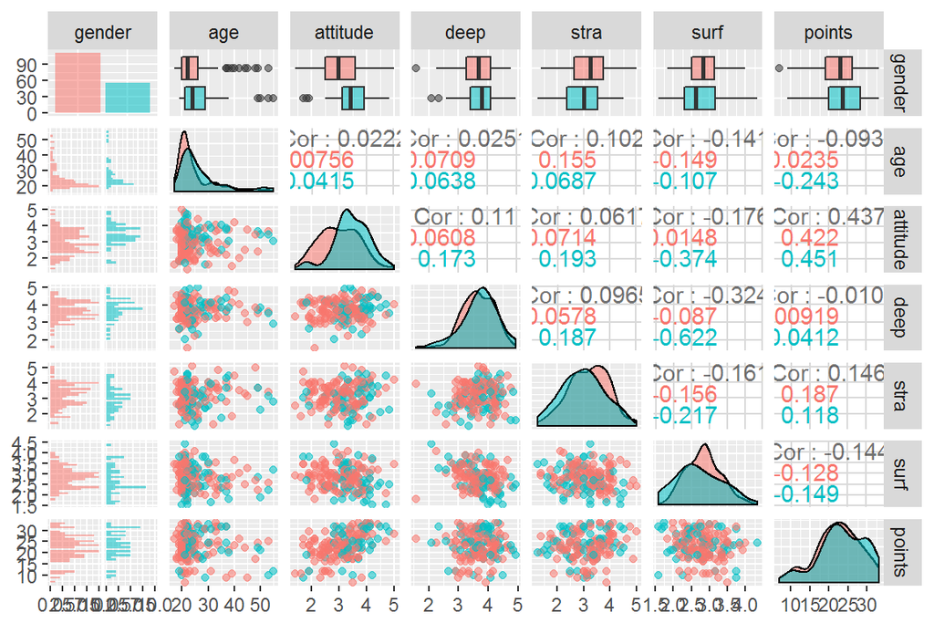

```r
p <- ggpairs(learning2014, mapping = aes(col=gender,alpha=0.3))
p
```

```r
summary(learning2014)
```

```
##  gender       age           attitude          deep            stra
##  F:110   Min.   :17.00   Min.   :1.400   Min.   :1.583   Min.   :1.250
##  M: 56   1st Qu.:21.00   1st Qu.:2.600   1st Qu.:3.333   1st Qu.:2.625
##          Median :22.00   Median :3.200   Median :3.667   Median :3.188
##          Mean   :25.51   Mean   :3.143   Mean   :3.680   Mean   :3.121
##          3rd Qu.:27.00   3rd Qu.:3.700   3rd Qu.:4.083   3rd Qu.:3.625
##          Max.   :55.00   Max.   :5.000   Max.   :4.917   Max.   :5.000
##       surf           points
##  Min.   :1.583   Min.   : 7.00
##  1st Qu.:2.417   1st Qu.:19.00
##  Median :2.833   Median :23.00
##  Mean   :2.787   Mean   :22.72
##  3rd Qu.:3.167   3rd Qu.:27.75
##  Max.   :4.333   Max.   :33.00
```

## 2. Show a graphical overview of the data

The figure shows the relationship among different variables. Totally there are 166 subjects including 110 females and 56 males. 7 variables include age, attitude, deep combined with deep questions, stra with strategiic questions, surf with surface questions, points. Most subjects are at the age of 20-30. The points of attitude and deep questions for male subjects are higher than that of female. But the points of strategic and surface quenstions for female subjects are higher than that of males. However there is little difference of the overall points between genders. The variable of points has a relatively close relationship with attitude, with correlation value 0.437.

## 3. Multiple regression

*create a regression model with three explanatory variables targeted points*

```r
model1 <- lm(points ~ attitude + stra + surf, data = learning2014)
summary(model1)
```

```
##
## Call:
## lm(formula = points ~ attitude + stra + surf, data = learning2014)
##
## Residuals:
##      Min       1Q   Median       3Q      Max
## -17.1550  -3.4346   0.5156   3.6401  10.8952
##
## Coefficients:
##             Estimate Std. Error t value Pr(>|t|)
## (Intercept)  11.0171     3.6837   2.991  0.00322 **
## attitude      3.3952     0.5741   5.913 1.93e-08 ***
## stra          0.8531     0.5416   1.575  0.11716
## surf         -0.5861     0.8014  -0.731  0.46563
## ---
## Signif. codes:  0 '***' 0.001 '**' 0.01 '*' 0.05 '.' 0.1 ' ' 1
##
## Residual standard error: 5.296 on 162 degrees of freedom
## Multiple R-squared:  0.2074, Adjusted R-squared:  0.1927
## F-statistic: 14.13 on 3 and 162 DF,  p-value: 3.156e-08
```

The target variable point is fitted to three explanatory variables: attitude, stra and surf. According to the results of the model, surf does not have a statistically significant relationship with the target variable. So, surf is removed from the fitting model and points is modelled according to attitude and stra again.

*remove variable surf and remodel*

```r
model2 <- lm(points ~ attitude + stra, data = learning2014)
```

## 4. Interpret fitted model

```r
summary(model2)
```

```
##
## Call:
## lm(formula = points ~ attitude + stra, data = learning2014)
##
## Residuals:
##      Min       1Q   Median       3Q      Max
## -17.6436  -3.3113   0.5575   3.7928  10.9295
##
## Coefficients:
##             Estimate Std. Error t value Pr(>|t|)
## (Intercept)   8.9729     2.3959   3.745  0.00025 ***
## attitude      3.4658     0.5652   6.132 6.31e-09 ***
## stra          0.9137     0.5345   1.709  0.08927 .
## ---
## Signif. codes:  0 '***' 0.001 '**' 0.01 '*' 0.05 '.' 0.1 ' ' 1
##
## Residual standard error: 5.289 on 163 degrees of freedom
## Multiple R-squared:  0.2048, Adjusted R-squared:  0.1951
## F-statistic: 20.99 on 2 and 163 DF,  p-value: 7.734e-09
```

In Model2, ‘points’ is the target and both ‘attitude’and ’stra’ are the explanatory variables. The formula is $points=8.9729+3.4658*attitude+0.9137*stra$. We could expect an average points of 8.9729 for all gender subjects with no any points in attitude and strategis question. If stra remains constant, points will differ by 3.4658 unit on average when attitude differed by 1 unit.Similarly, points will change 0.9137 unit when sta differed by one unit if attitude keeps constant. The regression modle account for 20.48% of the variance. Since the points can be affected by other factors apart from attitude and sta, so the multiple R-squared value is lower than 50%. However, we have statistically a significant predictor in attitude, we can still use the formula for prediction.

## 5. Diagnostic plots

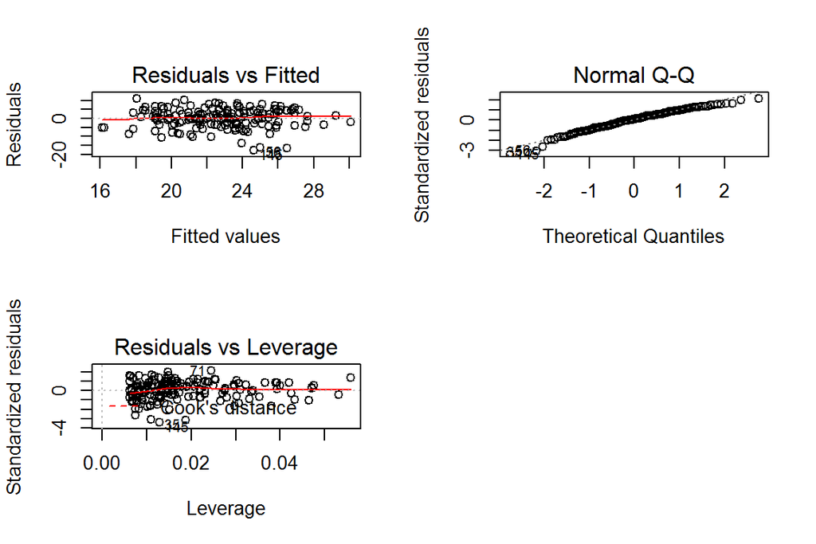

```r
par(mfrow=c(2,2))
plot(model2, which=c(1,2,5))
```

The Residuals vs Fitted values plot examines if the errors have constant variance. The graph shows a reasonable constant variance without any pattern. The Normal QQ-polt checks if the errors are normally distributed. We see from the graph a very good linear model fit, indicating a normally distributed error set. The Residuals vs Leverage confirms if there are any outliers with high leverage. From the graph, it shows that all the leverage are below 0.06, indicating good model fitting.

# Data analysis for logistic regression

## 1. create a new RMarkdown file and save it as an empty file named ‘chapter3.Rmd’

title: “Chapter3.Rmd” output: html_document

```r
getwd()
```

```
## [1] "D:/github/IODS-project"
```

```r
setwd('D:/github/IODS-project/data')
```

## 2. Read the joined student alcohol consumption data i

```r
library(readr)
alc <- read_csv("alc.txt")
```

*Print out the names of the variables in the data

```r
colnames(alc)
```

```
##  [1] "school"     "sex"        "age"        "address"    "famsize"
##  [6] "Pstatus"    "Medu"       "Fedu"       "Mjob"       "Fjob"
## [11] "reason"     "nursery"    "internet"   "guardian"   "traveltime"
## [16] "studytime"  "failures"   "schoolsup"  "famsup"     "paid"
## [21] "activities" "higher"     "romantic"   "famrel"     "freetime"
## [26] "goout"      "Dalc"       "Walc"       "health"     "absences"
## [31] "G1"         "G2"         "G3"         "alc_use"    "high_use"
```

the data set *alc.txt* used in the analysis combines two data sets regarding the performance in two distinct subjects: Mathematics (mat) and Portuguese language (por).  
*The variables not used for joining the two data have been combined by averaging (including the grade variables).* ‘alc_use’ is the average of ‘Dalc’ and ‘Walc’ *‘high_use’ is TRUE if ‘alc_use’ is higher than 2 and FALSE otherwise.

## 3. Choose 4 interesting variables in the data and for each of them, present your personal hypothesis about their relationships with alcohol consumption

- 4 variables I guess to be interesting are age, studytime, goout and final grade G3. I personally think that:
1. The older students are more likely to high use alcohol than the younger.
2. The more weekly study time, less high use alcohol.
3. Students with higher final grades are less likely to high use alcohol.
4. Students frequently going out with friends are more likely to high use alcohol.

## 4 Relationships of the varibles I selected with alcohol consumption

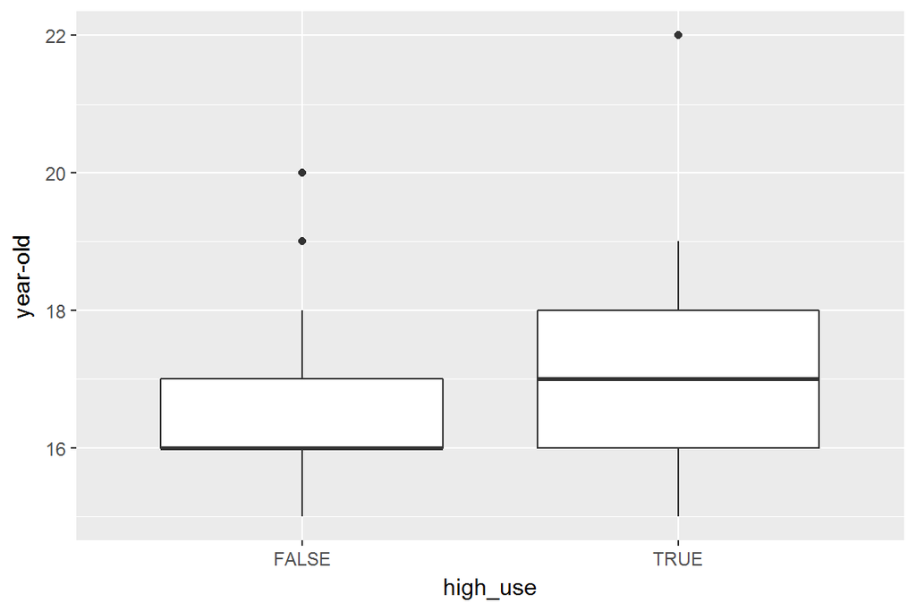

```r
library(ggplot2)
g1 <- ggplot(alc, aes(x = high_use, y = age))
g1 + geom_boxplot() + ylab("year-old")
```

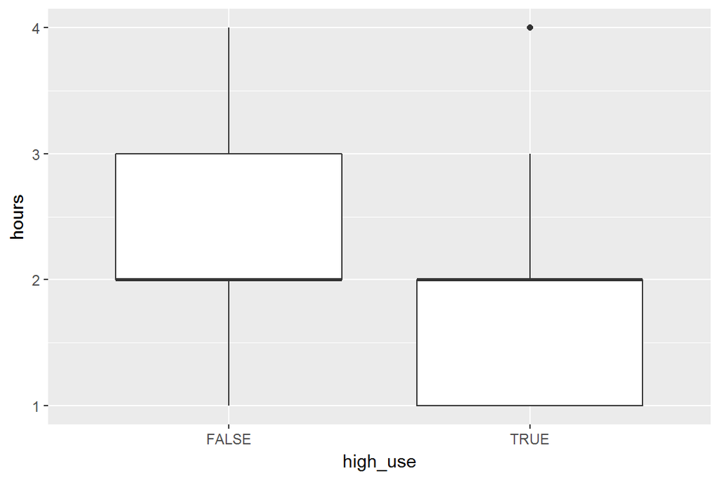

```r
g2 <- ggplot(alc, aes(x = high_use, y = studytime))
g2 + geom_boxplot() + ylab("hours")
```

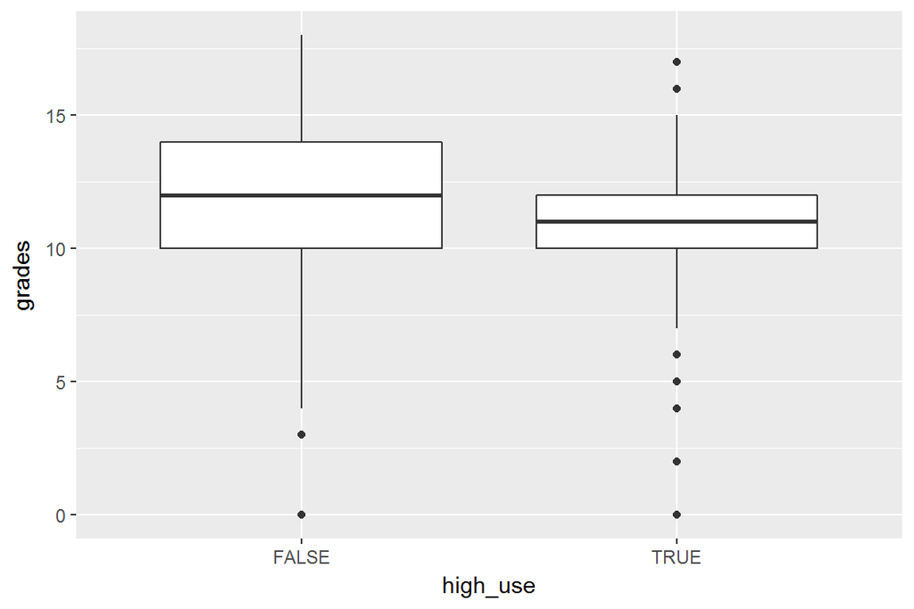

```r
g3 <- ggplot(alc, aes(x = high_use, y = G3))
g3 + geom_boxplot() + ylab("grades")
```

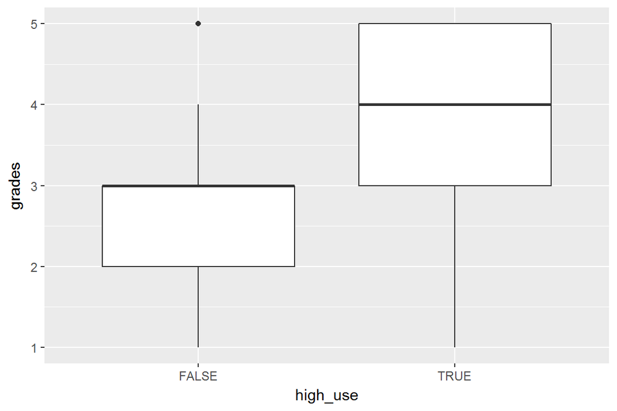

```r
g4 <- ggplot(alc, aes(x = high_use, y = goout))
g4 + geom_boxplot() + ylab("grades")
```

From the box plots, I find that: (1) students at the age of 16 are likely to low use accohol and students at the age of 17 are more likely to high use alcohol.But the relationship between age and alcohol consumption isn’t clear since there is a overlap distribution for age varible. (2) students who spend more than 2 hours on study every week are less likely to high use alcohol than students with less than 2-hour study time weekly. (3) It is hard to get the relationship between G3 and high use alcohol. (4) The students going out with friends frequently are more likely to high use alcohol. ## 5. Use logistic regression * find the model with glm()

```r
m <- glm(high_use ~ age + studytime + G3 + goout, data = alc, family = "binomial")
summary(m)
```

```
##
## Call:
## glm(formula = high_use ~ age + studytime + G3 + goout, family = "binomial",
##     data = alc)
##
## Deviance Residuals:
##     Min       1Q   Median       3Q      Max
## -1.7134  -0.7716  -0.5322   0.9388   2.5920
##
## Coefficients:
##             Estimate Std. Error z value Pr(>|z|)
## (Intercept) -3.72738    1.97479  -1.887 0.059096 .
## age          0.11830    0.11019   1.074 0.283016
## studytime   -0.59111    0.16763  -3.526 0.000421 ***
## G3          -0.02635    0.03896  -0.676 0.498767
## goout        0.71852    0.11798   6.090 1.13e-09 ***
## ---
## Signif. codes:  0 '***' 0.001 '**' 0.01 '*' 0.05 '.' 0.1 ' ' 1
##
## (Dispersion parameter for binomial family taken to be 1)
##
##     Null deviance: 465.68  on 381  degrees of freedom
## Residual deviance: 398.84  on 377  degrees of freedom
## AIC: 408.84
##
## Number of Fisher Scoring iterations: 4
```

According to the m modle, The coefficients of age and G3 have no significant difference, so it may reveals that age and G3 have no significant correction with high use alcohol. To check if the model can be improved without the varibles age and G3, another model named m1 is built and conduct a likelihood radio test. * fit another model named m1 without age and G3

```r
m1 <- glm(high_use ~ studytime + goout, data = alc, family = "binomial")
summary(m1)
```

```
##
## Call:
## glm(formula = high_use ~ studytime + goout, family = "binomial",
##     data = alc)
##
## Deviance Residuals:
##     Min       1Q   Median       3Q      Max
## -1.6229  -0.7609  -0.5434   1.0122   2.5411
##
## Coefficients:
##             Estimate Std. Error z value Pr(>|z|)
## (Intercept)  -2.1254     0.5078  -4.185 2.85e-05 ***
## studytime    -0.6031     0.1645  -3.666 0.000246 ***
## goout         0.7467     0.1167   6.398 1.58e-10 ***
## ---
## Signif. codes:  0 '***' 0.001 '**' 0.01 '*' 0.05 '.' 0.1 ' ' 1
##
## (Dispersion parameter for binomial family taken to be 1)
##
##     Null deviance: 465.68  on 381  degrees of freedom
## Residual deviance: 400.81  on 379  degrees of freedom
## AIC: 406.81
##
## Number of Fisher Scoring iterations: 4
```

- conduct a likelihood radio test

```r
anova(m, m1, test="LRT")
```

```
## Analysis of Deviance Table
##
## Model 1: high_use ~ age + studytime + G3 + goout
## Model 2: high_use ~ studytime + goout
##   Resid. Df Resid. Dev Df Deviance Pr(>Chi)
## 1       377     398.84
## 2       379     400.81 -2  -1.9654   0.3743
```

- The likelihood ratio test is not significant and we would conclude that the variable age and G3 should be away in the model.
- compute odds ratios (OR)

```r
library(dplyr)
OR <- coef(m1) %>% exp
```

- compute confidence intervals (CI)

```r
CI <- confint(m1) %>% exp
```

- print out the odds ratios with their confidence intervals

```r
cbind(OR, CI)
```

```
##                    OR      2.5 %    97.5 %
## (Intercept) 0.1193805 0.04302918 0.3165390
## studytime   0.5471050 0.39199804 0.7484539
## goout       2.1100719 1.68858285 2.6709107
```

- According to the odds radios of studytime and goout, it can reveal that:
1. Studytime associates with less probability of high use of alcohol because OR (studytime) < 1 which is related to low odds.
2. Goout is responsible for high probability of high use of alcohol because OR(goout) > 1.
3. my previously hypothesis about the relationships of these two variables with high use of alcohol is right.

## 6. Explore the predictive power of you model

- predict() the probability of high_use

```r
probabilities <- predict(m1, type = "response")
```

- add the predicted probabilities to ‘alc’

```r
alc <- mutate(alc, probability = probabilities)
```

- use the probabilities to make a prediction of high_use

```r
alc <- mutate(alc, prediction = probability > 0.5)
```

- see the last ten original classes, predicted probabilities, and class predictions

```r
select(alc, studytime, goout, high_use, probability, prediction) %>% tail(10)
```

```
## # A tibble: 10 x 5
##    studytime goout high_use probability prediction
##        <int> <int>    <lgl>       <dbl>      <lgl>
##  1         1     2    FALSE  0.22528831      FALSE
##  2         1     3     TRUE  0.38027339      FALSE
##  3         3     3    FALSE  0.15516959      FALSE
##  4         1     3    FALSE  0.38027339      FALSE
##  5         3     2    FALSE  0.08007420      FALSE
##  6         2     4    FALSE  0.41464868      FALSE
##  7         2     2    FALSE  0.13726140      FALSE
##  8         2     1    FALSE  0.07011354      FALSE
##  9         1     5     TRUE  0.73205149       TRUE
## 10         1     1     TRUE  0.12112368      FALSE
```

- tabulate the target variable versus the predictions

```r
table(high_use = alc$high_use, prediction = alc$prediction)
```

```
##         prediction
## high_use FALSE TRUE
##    FALSE   247   21
##    TRUE     73   41
```

- initialize a plot of ‘high_use’ versus ‘probability’ in ‘alc’

```r
g <- ggplot(alc, aes(x = probability, y =high_use, col=prediction))
```

- define the geom as points and draw the plot

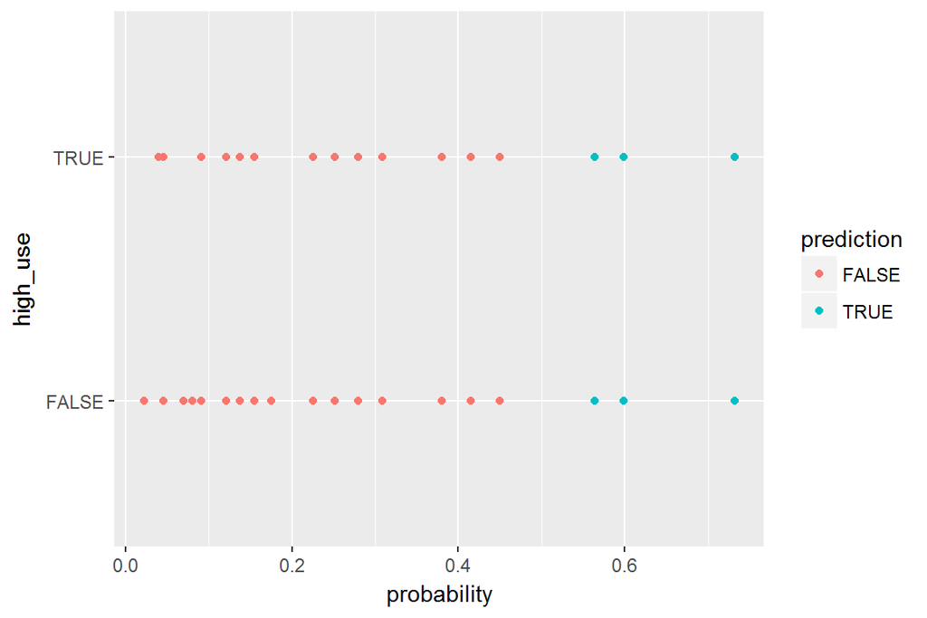

```r
g + geom_point()
```

* tabulate the target variable versus the predictions

```r
table(high_use = alc$high_use, prediction = alc$prediction) %>% prop.table %>% addmargins
```

```
##         prediction
## high_use      FALSE       TRUE        Sum
##    FALSE 0.64659686 0.05497382 0.70157068
##    TRUE  0.19109948 0.10732984 0.29842932
##    Sum   0.83769634 0.16230366 1.00000000
```

- define a loss function (average prediction error)

```r
loss_func <- function(class, prob) {
  n_wrong <- abs(class - prob) > 0.5
  mean(n_wrong)
}
```

- call loss_func to compute the average number of wrong predictions in the (training) data

```r
 loss_func(class = alc$high_use, prob = alc$probability)
```

```
## [1] 0.2460733
```

- It reveals that 24.6% of prediction are incorrect.
- New observations

```r
new_studytime <- c(2, 3, 4)
new_goout <- c(2, 3, 4)
new_data <- data.frame(studytime = new_studytime, goout = new_goout)
new_data
```

```
##   studytime goout
## 1         2     2
## 2         3     3
## 3         4     4
```

```r
predict(m1, newdata = new_data)
```

```
##         1         2         3
## -1.838225 -1.694617 -1.551010
```

created at 19:30 29.11.2017 @author:Zilan Wen

# Chapter 4 Clustering and classification–Analysis exercises

## 1.Create a new RMarkdown

title: “chapter4.Rmd” output: html_document

## 2.Load the Boston data

- Load the Boston data from the MASS package

```r
library(MASS)
data("Boston")
```

## 3. Explore the structure and the dimensions of the data

```r
str(Boston)
```

```
## 'data.frame':    506 obs. of  14 variables:
##  $ crim   : num  0.00632 0.02731 0.02729 0.03237 0.06905 ...
##  $ zn     : num  18 0 0 0 0 0 12.5 12.5 12.5 12.5 ...
##  $ indus  : num  2.31 7.07 7.07 2.18 2.18 2.18 7.87 7.87 7.87 7.87 ...
##  $ chas   : int  0 0 0 0 0 0 0 0 0 0 ...
##  $ nox    : num  0.538 0.469 0.469 0.458 0.458 0.458 0.524 0.524 0.524 0.524 ...
##  $ rm     : num  6.58 6.42 7.18 7 7.15 ...
##  $ age    : num  65.2 78.9 61.1 45.8 54.2 58.7 66.6 96.1 100 85.9 ...
##  $ dis    : num  4.09 4.97 4.97 6.06 6.06 ...
##  $ rad    : int  1 2 2 3 3 3 5 5 5 5 ...
##  $ tax    : num  296 242 242 222 222 222 311 311 311 311 ...
##  $ ptratio: num  15.3 17.8 17.8 18.7 18.7 18.7 15.2 15.2 15.2 15.2 ...
##  $ black  : num  397 397 393 395 397 ...
##  $ lstat  : num  4.98 9.14 4.03 2.94 5.33 ...
##  $ medv   : num  24 21.6 34.7 33.4 36.2 28.7 22.9 27.1 16.5 18.9 ...
```

```r
dim(Boston)
```

```
## [1] 506  14
```

The Boston data is about housing value in suburbs of Boston. 14 Variables used to assess housing value are as following:

crim per capita crime rate by town.  
zn proportion of residential land zoned for lots over 25,000 sq.ft.  
indus proportion of non-retail business acres per town.  
chas Charles River dummy variable (= 1 if tract bounds river; 0 otherwise).  
nox nitrogen oxides concentration (parts per 10 million).  
rm average number of rooms per dwelling.  
age proportion of owner-occupied units built prior to 1940.  
dis weighted mean of distances to five Boston employment centres.  
rad index of accessibility to radial highways.  
tax full-value property-tax rate per $10,000.  
ptratio pupil-teacher ratio by town.  
black 1000(Bk ??? 0.63)2 where Bk is the proportion of blacks by town.  
lstat lower status of the population (percent).  
medv median value of owner-occupied homes in $1000s

- Overview of the data
- plot matrix of the variables

```r
summary(Boston)
```

```
##       crim                zn             indus            chas
##  Min.   : 0.00632   Min.   :  0.00   Min.   : 0.46   Min.   :0.00000
##  1st Qu.: 0.08204   1st Qu.:  0.00   1st Qu.: 5.19   1st Qu.:0.00000
##  Median : 0.25651   Median :  0.00   Median : 9.69   Median :0.00000
##  Mean   : 3.61352   Mean   : 11.36   Mean   :11.14   Mean   :0.06917
##  3rd Qu.: 3.67708   3rd Qu.: 12.50   3rd Qu.:18.10   3rd Qu.:0.00000
##  Max.   :88.97620   Max.   :100.00   Max.   :27.74   Max.   :1.00000
##       nox               rm             age              dis
##  Min.   :0.3850   Min.   :3.561   Min.   :  2.90   Min.   : 1.130
##  1st Qu.:0.4490   1st Qu.:5.886   1st Qu.: 45.02   1st Qu.: 2.100
##  Median :0.5380   Median :6.208   Median : 77.50   Median : 3.207
##  Mean   :0.5547   Mean   :6.285   Mean   : 68.57   Mean   : 3.795
##  3rd Qu.:0.6240   3rd Qu.:6.623   3rd Qu.: 94.08   3rd Qu.: 5.188
##  Max.   :0.8710   Max.   :8.780   Max.   :100.00   Max.   :12.127
##       rad              tax           ptratio          black
##  Min.   : 1.000   Min.   :187.0   Min.   :12.60   Min.   :  0.32
##  1st Qu.: 4.000   1st Qu.:279.0   1st Qu.:17.40   1st Qu.:375.38
##  Median : 5.000   Median :330.0   Median :19.05   Median :391.44
##  Mean   : 9.549   Mean   :408.2   Mean   :18.46   Mean   :356.67
##  3rd Qu.:24.000   3rd Qu.:666.0   3rd Qu.:20.20   3rd Qu.:396.23
##  Max.   :24.000   Max.   :711.0   Max.   :22.00   Max.   :396.90
##      lstat            medv
##  Min.   : 1.73   Min.   : 5.00
##  1st Qu.: 6.95   1st Qu.:17.02
##  Median :11.36   Median :21.20
##  Mean   :12.65   Mean   :22.53
##  3rd Qu.:16.95   3rd Qu.:25.00
##  Max.   :37.97   Max.   :50.00
```

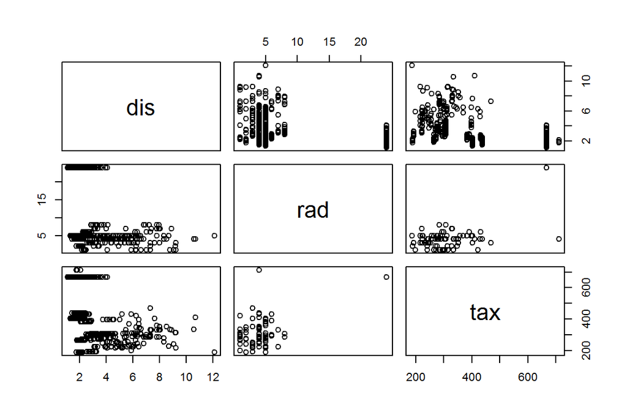

```r
pairs(Boston[8:10])
```

* calculate the correlation matrix and round it

```r
library(tidyr)
cor_matrix<-cor(Boston) %>% round(2)
cor_matrix
```

```
##          crim    zn indus  chas   nox    rm   age   dis   rad   tax
## crim     1.00 -0.20  0.41 -0.06  0.42 -0.22  0.35 -0.38  0.63  0.58
## zn      -0.20  1.00 -0.53 -0.04 -0.52  0.31 -0.57  0.66 -0.31 -0.31
## indus    0.41 -0.53  1.00  0.06  0.76 -0.39  0.64 -0.71  0.60  0.72
## chas    -0.06 -0.04  0.06  1.00  0.09  0.09  0.09 -0.10 -0.01 -0.04
## nox      0.42 -0.52  0.76  0.09  1.00 -0.30  0.73 -0.77  0.61  0.67
## rm      -0.22  0.31 -0.39  0.09 -0.30  1.00 -0.24  0.21 -0.21 -0.29
## age      0.35 -0.57  0.64  0.09  0.73 -0.24  1.00 -0.75  0.46  0.51
## dis     -0.38  0.66 -0.71 -0.10 -0.77  0.21 -0.75  1.00 -0.49 -0.53
## rad      0.63 -0.31  0.60 -0.01  0.61 -0.21  0.46 -0.49  1.00  0.91
## tax      0.58 -0.31  0.72 -0.04  0.67 -0.29  0.51 -0.53  0.91  1.00
## ptratio  0.29 -0.39  0.38 -0.12  0.19 -0.36  0.26 -0.23  0.46  0.46
## black   -0.39  0.18 -0.36  0.05 -0.38  0.13 -0.27  0.29 -0.44 -0.44
## lstat    0.46 -0.41  0.60 -0.05  0.59 -0.61  0.60 -0.50  0.49  0.54
## medv    -0.39  0.36 -0.48  0.18 -0.43  0.70 -0.38  0.25 -0.38 -0.47
##         ptratio black lstat  medv
## crim       0.29 -0.39  0.46 -0.39
## zn        -0.39  0.18 -0.41  0.36
## indus      0.38 -0.36  0.60 -0.48
## chas      -0.12  0.05 -0.05  0.18
## nox        0.19 -0.38  0.59 -0.43
## rm        -0.36  0.13 -0.61  0.70
## age        0.26 -0.27  0.60 -0.38
## dis       -0.23  0.29 -0.50  0.25
## rad        0.46 -0.44  0.49 -0.38
## tax        0.46 -0.44  0.54 -0.47
## ptratio    1.00 -0.18  0.37 -0.51
## black     -0.18  1.00 -0.37  0.33
## lstat      0.37 -0.37  1.00 -0.74
## medv      -0.51  0.33 -0.74  1.00
```

- visualize the correlation matrix

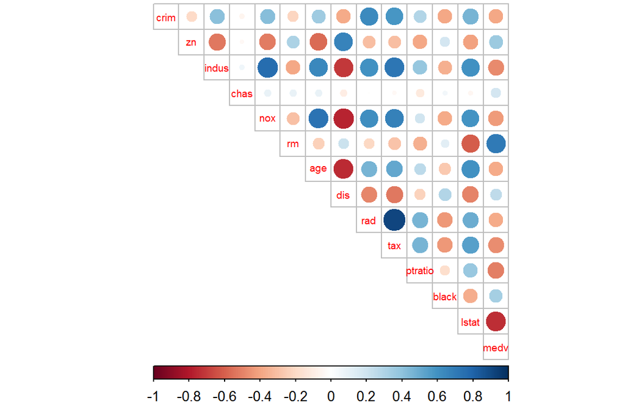

```r
library(corrplot)
corrplot(cor_matrix, method="circle", type = 'upper', cl.pos ="b", tl.pos = 'd', tl.cex = 0.6)
```

From the graphy, we can see that: 1. crim is positively related to rad and tax,(0.63 & 0.58). 2. zn is positive correlated with dis, which means that more proportion of residential land could be reached wth more distances to Boston centres. 3. the proportion of non-retail business acres per town positively affects nitrogen oxides concentration and tax, but has a negative correlation with distance. 4. Chas seems to have no relationship with others. 5. Age is negatively related to dis, which reveals the proportion of owner-occupied units built prior to 1940 becomes downwards with increasing distance. 6. Tax has a positive relationship with rad.

## 4. Standardize the dataset and print out summaries of the scaled data.

- center and standardize variables

```r
boston_scaled <- scale(Boston)
```

- summaries of the scaled variables

```r
summary(boston_scaled)
```

```
##       crim                 zn               indus
##  Min.   :-0.419367   Min.   :-0.48724   Min.   :-1.5563
##  1st Qu.:-0.410563   1st Qu.:-0.48724   1st Qu.:-0.8668
##  Median :-0.390280   Median :-0.48724   Median :-0.2109
##  Mean   : 0.000000   Mean   : 0.00000   Mean   : 0.0000
##  3rd Qu.: 0.007389   3rd Qu.: 0.04872   3rd Qu.: 1.0150
##  Max.   : 9.924110   Max.   : 3.80047   Max.   : 2.4202
##       chas              nox                rm               age
##  Min.   :-0.2723   Min.   :-1.4644   Min.   :-3.8764   Min.   :-2.3331
##  1st Qu.:-0.2723   1st Qu.:-0.9121   1st Qu.:-0.5681   1st Qu.:-0.8366
##  Median :-0.2723   Median :-0.1441   Median :-0.1084   Median : 0.3171
##  Mean   : 0.0000   Mean   : 0.0000   Mean   : 0.0000   Mean   : 0.0000
##  3rd Qu.:-0.2723   3rd Qu.: 0.5981   3rd Qu.: 0.4823   3rd Qu.: 0.9059
##  Max.   : 3.6648   Max.   : 2.7296   Max.   : 3.5515   Max.   : 1.1164
##       dis               rad               tax             ptratio
##  Min.   :-1.2658   Min.   :-0.9819   Min.   :-1.3127   Min.   :-2.7047
##  1st Qu.:-0.8049   1st Qu.:-0.6373   1st Qu.:-0.7668   1st Qu.:-0.4876
##  Median :-0.2790   Median :-0.5225   Median :-0.4642   Median : 0.2746
##  Mean   : 0.0000   Mean   : 0.0000   Mean   : 0.0000   Mean   : 0.0000
##  3rd Qu.: 0.6617   3rd Qu.: 1.6596   3rd Qu.: 1.5294   3rd Qu.: 0.8058
##  Max.   : 3.9566   Max.   : 1.6596   Max.   : 1.7964   Max.   : 1.6372
##      black             lstat              medv
##  Min.   :-3.9033   Min.   :-1.5296   Min.   :-1.9063
##  1st Qu.: 0.2049   1st Qu.:-0.7986   1st Qu.:-0.5989
##  Median : 0.3808   Median :-0.1811   Median :-0.1449
##  Mean   : 0.0000   Mean   : 0.0000   Mean   : 0.0000
##  3rd Qu.: 0.4332   3rd Qu.: 0.6024   3rd Qu.: 0.2683
##  Max.   : 0.4406   Max.   : 3.5453   Max.   : 2.9865
```

The means of all variables become zero.

- class of the boston_scaled object

```r
class(boston_scaled)
```

```
## [1] "matrix"
```

- change the object to data frame

```r
boston_scaled <- as.data.frame(boston_scaled)
summary(boston_scaled)
```

```
##       crim                 zn               indus
##  Min.   :-0.419367   Min.   :-0.48724   Min.   :-1.5563
##  1st Qu.:-0.410563   1st Qu.:-0.48724   1st Qu.:-0.8668
##  Median :-0.390280   Median :-0.48724   Median :-0.2109
##  Mean   : 0.000000   Mean   : 0.00000   Mean   : 0.0000
##  3rd Qu.: 0.007389   3rd Qu.: 0.04872   3rd Qu.: 1.0150
##  Max.   : 9.924110   Max.   : 3.80047   Max.   : 2.4202
##       chas              nox                rm               age
##  Min.   :-0.2723   Min.   :-1.4644   Min.   :-3.8764   Min.   :-2.3331
##  1st Qu.:-0.2723   1st Qu.:-0.9121   1st Qu.:-0.5681   1st Qu.:-0.8366
##  Median :-0.2723   Median :-0.1441   Median :-0.1084   Median : 0.3171
##  Mean   : 0.0000   Mean   : 0.0000   Mean   : 0.0000   Mean   : 0.0000
##  3rd Qu.:-0.2723   3rd Qu.: 0.5981   3rd Qu.: 0.4823   3rd Qu.: 0.9059
##  Max.   : 3.6648   Max.   : 2.7296   Max.   : 3.5515   Max.   : 1.1164
##       dis               rad               tax             ptratio
##  Min.   :-1.2658   Min.   :-0.9819   Min.   :-1.3127   Min.   :-2.7047
##  1st Qu.:-0.8049   1st Qu.:-0.6373   1st Qu.:-0.7668   1st Qu.:-0.4876
##  Median :-0.2790   Median :-0.5225   Median :-0.4642   Median : 0.2746
##  Mean   : 0.0000   Mean   : 0.0000   Mean   : 0.0000   Mean   : 0.0000
##  3rd Qu.: 0.6617   3rd Qu.: 1.6596   3rd Qu.: 1.5294   3rd Qu.: 0.8058
##  Max.   : 3.9566   Max.   : 1.6596   Max.   : 1.7964   Max.   : 1.6372
##      black             lstat              medv
##  Min.   :-3.9033   Min.   :-1.5296   Min.   :-1.9063
##  1st Qu.: 0.2049   1st Qu.:-0.7986   1st Qu.:-0.5989
##  Median : 0.3808   Median :-0.1811   Median :-0.1449
##  Mean   : 0.0000   Mean   : 0.0000   Mean   : 0.0000
##  3rd Qu.: 0.4332   3rd Qu.: 0.6024   3rd Qu.: 0.2683
##  Max.   : 0.4406   Max.   : 3.5453   Max.   : 2.9865
```

- Create a categorical variable of the crime rate in the Boston dataset (from the scaled crime rate).
- summary of the scaled crime rate

```r
summary(boston_scaled$crim)
```

```
##      Min.   1st Qu.    Median      Mean   3rd Qu.      Max.
## -0.419367 -0.410563 -0.390280  0.000000  0.007389  9.924110
```

- create a quantile vector of crim and print it

```r
bins <- quantile(boston_scaled$crim) %>% round(4)
bins
```

```
##      0%     25%     50%     75%    100%
## -0.4194 -0.4106 -0.3903  0.0074  9.9241
```

```r
getwd()
```

```
## [1] "D:/github/IODS-project"
```

```r
setwd('D:/github/IODS-project')
```

- create a categorical variable ‘crime’

```r
crime <- cut(boston_scaled$crim, breaks = bins, include.lowest = TRUE, label = c('low', 'med_low', 'med_high', 'high'))
table(crime)
```

[output not shown]

```r
boston_scaled <- dplyr::select(boston_scaled, -crim)
boston_scaled <- data.frame(boston_scaled, crime)
```

- Splitting the original data to test and train sets
- number of rows in the Boston dataset

```r
n <- nrow(boston_scaled)
n
```

```
## [1] 506
```

- choose randomly 80% of the rows and save the row numbers to ind

```r
ind <- sample(n,  size = n * 0.8)
```

- create train set

```r
train <- boston_scaled[ind,]
```

## 5. linear discriminant analysis

- linear discriminant analysis on the train set

```r
lda.fit <- lda(crime ~ ., data = train)
lda.fit
```

```
## Call:
## lda(crime ~ ., data = train)
##
## Prior probabilities of groups:
##       low   med_low  med_high      high
## 0.2481390 0.2655087 0.2555831 0.2307692
##
## Group means:
##                  zn      indus        chas        nox         rm
## low       1.0554792 -0.8936244 -0.11484506 -0.8696849  0.3965255
## med_low  -0.1125661 -0.3205678 -0.01476176 -0.6017844 -0.1505304
## med_high -0.3856672  0.2133715  0.22458650  0.4330319  0.1080379
## high     -0.4872402  1.0149946 -0.10299142  1.0304117 -0.3713152
##                 age        dis        rad        tax    ptratio
## low      -0.8875990  0.8411900 -0.6775274 -0.7254613 -0.4381328
## med_low  -0.3870326  0.3710899 -0.5396577 -0.4749710 -0.1124204
## med_high  0.4468563 -0.3762691 -0.4187879 -0.3004395 -0.3256655
## high      0.8196952 -0.8569360  1.6596029  1.5294129  0.8057784
##                black       lstat       medv
## low       0.37345987 -0.75481260  0.4833254
## med_low   0.32322693 -0.15942781  0.0160450
## med_high  0.06296941  0.02628649  0.1716675
## high     -0.83667274  0.90053947 -0.7271468
##
## Coefficients of linear discriminants:
##                 LD1          LD2          LD3
## zn       0.12580925  0.831873157 -1.086890269
## indus    0.05622545 -0.278988936  0.164105456
## chas    -0.08258534 -0.047706238  0.032049007
## nox      0.24206482 -0.733624154 -1.377610726
## rm      -0.08103941 -0.125285182 -0.115618918
## age      0.27108205 -0.348977141 -0.224794244
## dis     -0.09690203 -0.480451186  0.180678529
## rad      3.40262628  0.970606383 -0.009417971
## tax     -0.01337972 -0.127467687  0.647683279
## ptratio  0.14755566  0.060560331 -0.427287693
## black   -0.16891126  0.008825668  0.105870368
## lstat    0.20479001 -0.309911401  0.432341093
## medv     0.17358576 -0.473815106 -0.149112979
##
## Proportion of trace:
##    LD1    LD2    LD3
## 0.9398 0.0436 0.0166
```

- the function for lda biplot arrows

```r
lda.arrows <- function(x, myscale = 1, arrow_heads = 0.1, color = "red", tex = 0.75, choices = c(1,2)){
  heads <- coef(x)
  arrows(x0 = 0, y0 = 0,
         x1 = myscale * heads[,choices[1]],
         y1 = myscale * heads[,choices[2]], col=color, length = arrow_heads)
  text(myscale * heads[,choices], labels = row.names(heads),
       cex = tex, col=color, pos=3)
}
lda.arrows
```

```
## function(x, myscale = 1, arrow_heads = 0.1, color = "red", tex = 0.75, choices = c(1,2)){
##   heads <- coef(x)
##   arrows(x0 = 0, y0 = 0,
##          x1 = myscale * heads[,choices[1]],
##          y1 = myscale * heads[,choices[2]], col=color, length = arrow_heads)
##   text(myscale * heads[,choices], labels = row.names(heads),
##        cex = tex, col=color, pos=3)
## }
```

- target classes as numeric

```r
classes <- as.numeric(train$crime)
```

- plot the lda results

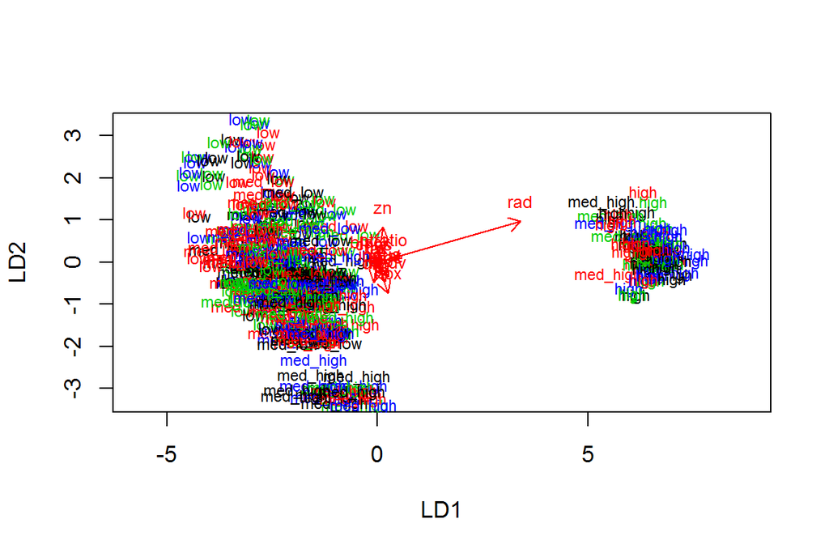

```r
plot(lda.fit, dimen = 2, col = classes, pch = classes)
lda.arrows(lda.fit, myscale = 1)
```

## 6. Save the crime categories from the test set

- create test set

```r
test <- boston_scaled[-ind,]
```

- save the correct classes from test data

```r
correct_classes <- test$crime
```

- Remove the categorical crime variable from the test dataset

```r
test <- dplyr::select(test, -crime)
```

- Predict classes with test data

```r
lda.pred <- predict(lda.fit, newdata = test)
```

- Cross tabulate the results

```r
table(correct = correct_classes, predicted = lda.pred$class)
```

```
##           predicted
## correct    low med_low med_high high
##   low       11      13        1    0
##   med_low    4      11        6    0
##   med_high   0       5       17    1
##   high       0       0        1   32
```

## 7. Determin the K by K-means

- Reload the Boston dataset and standardize the dataset

```r
data('Boston')
```

- center and standardize variables

```r
boston_scaled <- scale(Boston)
```

- summaries of the scaled variables

```r
summary(boston_scaled)
```

```
##       crim                 zn               indus
##  Min.   :-0.419367   Min.   :-0.48724   Min.   :-1.5563
##  1st Qu.:-0.410563   1st Qu.:-0.48724   1st Qu.:-0.8668
##  Median :-0.390280   Median :-0.48724   Median :-0.2109
##  Mean   : 0.000000   Mean   : 0.00000   Mean   : 0.0000
##  3rd Qu.: 0.007389   3rd Qu.: 0.04872   3rd Qu.: 1.0150
##  Max.   : 9.924110   Max.   : 3.80047   Max.   : 2.4202
##       chas              nox                rm               age
##  Min.   :-0.2723   Min.   :-1.4644   Min.   :-3.8764   Min.   :-2.3331
##  1st Qu.:-0.2723   1st Qu.:-0.9121   1st Qu.:-0.5681   1st Qu.:-0.8366
##  Median :-0.2723   Median :-0.1441   Median :-0.1084   Median : 0.3171
##  Mean   : 0.0000   Mean   : 0.0000   Mean   : 0.0000   Mean   : 0.0000
##  3rd Qu.:-0.2723   3rd Qu.: 0.5981   3rd Qu.: 0.4823   3rd Qu.: 0.9059
##  Max.   : 3.6648   Max.   : 2.7296   Max.   : 3.5515   Max.   : 1.1164
##       dis               rad               tax             ptratio
##  Min.   :-1.2658   Min.   :-0.9819   Min.   :-1.3127   Min.   :-2.7047
##  1st Qu.:-0.8049   1st Qu.:-0.6373   1st Qu.:-0.7668   1st Qu.:-0.4876
##  Median :-0.2790   Median :-0.5225   Median :-0.4642   Median : 0.2746
##  Mean   : 0.0000   Mean   : 0.0000   Mean   : 0.0000   Mean   : 0.0000
##  3rd Qu.: 0.6617   3rd Qu.: 1.6596   3rd Qu.: 1.5294   3rd Qu.: 0.8058
##  Max.   : 3.9566   Max.   : 1.6596   Max.   : 1.7964   Max.   : 1.6372
##      black             lstat              medv
##  Min.   :-3.9033   Min.   :-1.5296   Min.   :-1.9063
##  1st Qu.: 0.2049   1st Qu.:-0.7986   1st Qu.:-0.5989
##  Median : 0.3808   Median :-0.1811   Median :-0.1449
##  Mean   : 0.0000   Mean   : 0.0000   Mean   : 0.0000
##  3rd Qu.: 0.4332   3rd Qu.: 0.6024   3rd Qu.: 0.2683
##  Max.   : 0.4406   Max.   : 3.5453   Max.   : 2.9865
```

- manhattan distance matrix

```r
dist_man <- dist(boston_scaled, method = "manhattan" )
summary(dist_man)
```

```
##    Min. 1st Qu.  Median    Mean 3rd Qu.    Max.
##  0.2662  8.4832 12.6090 13.5488 17.7568 48.8618
```

- Run k-means algorithm on the dataset.

```r
km <-kmeans(boston_scaled, centers = 3)
```

- plot the Boston scaled dataset with clusters

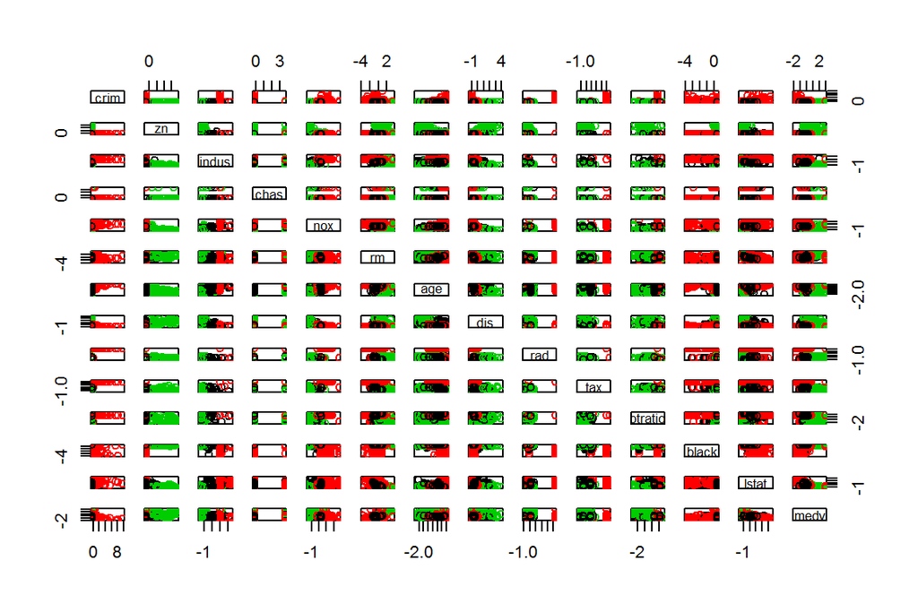

```r
pairs(boston_scaled, col = km$cluster)
```

```r
library(ggplot2)
set.seed(123)
```

- determine the number of clusters

```r
k_max <- 10
```

- calculate the total within sum of squares avd visualize the results

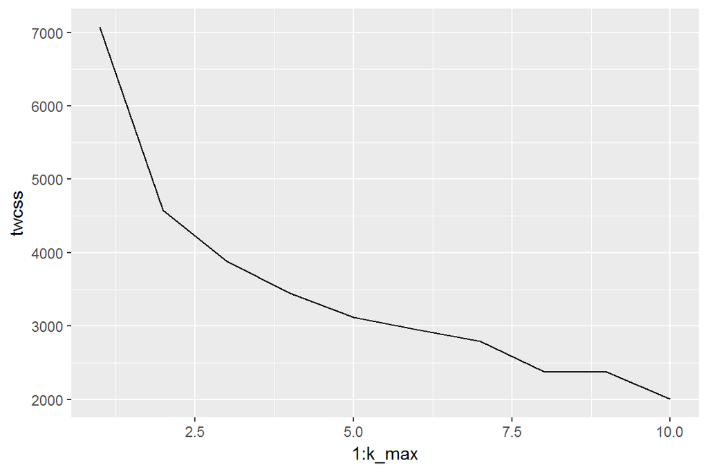

```r
twcss <- sapply(1:k_max, function(k){kmeans(boston_scaled, k)$tot.withinss})
qplot(x = 1:k_max, y = twcss, geom = 'line')
```

Suggested number of cluster: 2 * k-means clustering and plot the boston scaled dataset with clusters

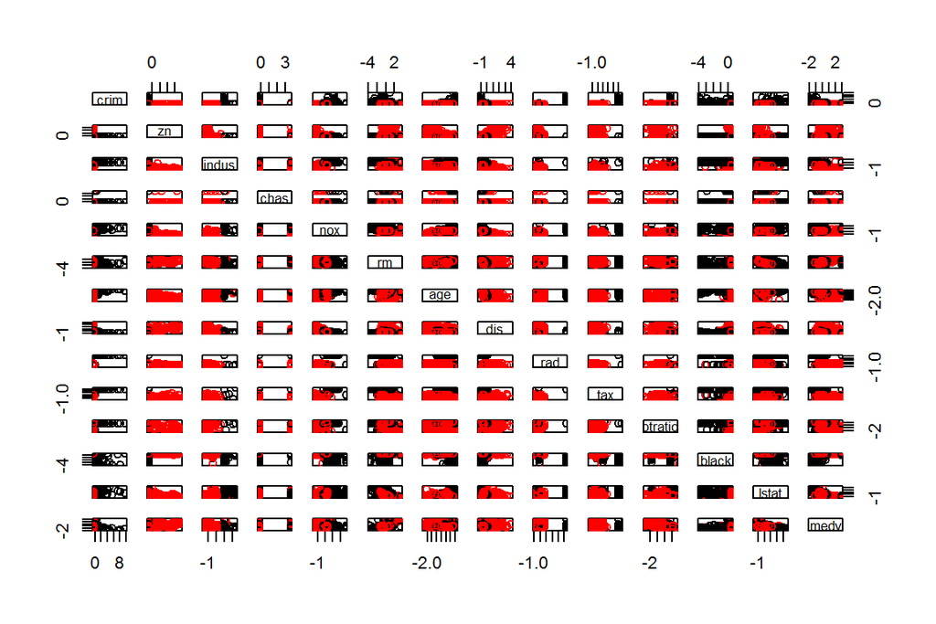

```r
km <-kmeans(boston_scaled, centers = 2)
pairs(boston_scaled, col = km$cluster)
```

The plot shows that the k-means method could classify the results quite well for most of the variables. The red group and black group are divided obviously in variables including indus, nox, rm, rad, tax, black, lstat, medv.

## Additional question

- use the standardized the dataset ‘boston_scaled’ to perform k-means. The number of cluster is 4

```r
data('Boston')
boston_scaled <- scale(Boston)
fit <-kmeans(boston_scaled, 4)
```

- get cluster means

```r
aggregate(boston_scaled,by=list(fit$cluster),FUN=mean)
```

```
##   Group.1       crim         zn      indus          chas        nox
## 1       1  1.9480908 -0.4872402  1.0149946 -0.2723290677  1.0357640
## 2       2  0.1886274 -0.4872402  1.2111512  0.1275326750  1.0860073
## 3       3 -0.3983105  1.2815288 -0.9887540 -0.0162575076 -0.8310342
## 4       4 -0.3881234 -0.3437504 -0.4317095  0.0005392655 -0.4538971
##           rm        age        dis        rad        tax     ptratio
## 1 -0.6389486  0.8260197 -0.9301775  1.6596029  1.5294129  0.80577843
## 2 -0.3665114  0.8044599 -0.8146389  0.7955609  0.9872011  0.34603822
## 3  1.0380929 -0.9191589  0.9190672 -0.5925129 -0.6744393 -0.85783203
## 4 -0.2322163 -0.1667989  0.2006333 -0.5787706 -0.6161614  0.09165441
##         black      lstat        medv
## 1 -2.13287198  1.4464782 -1.18461968
## 2  0.04414302  0.5301732 -0.40331922
## 3  0.35631209 -0.9522357  1.08435053
## 4  0.31468080 -0.1356461 -0.09388818
```

- get cluster means

```r
aggregate(boston_scaled,by=list(fit$cluster),FUN=mean)
```

```
##   Group.1       crim         zn      indus          chas        nox
## 1       1  1.9480908 -0.4872402  1.0149946 -0.2723290677  1.0357640
## 2       2  0.1886274 -0.4872402  1.2111512  0.1275326750  1.0860073
## 3       3 -0.3983105  1.2815288 -0.9887540 -0.0162575076 -0.8310342
## 4       4 -0.3881234 -0.3437504 -0.4317095  0.0005392655 -0.4538971
##           rm        age        dis        rad        tax     ptratio
## 1 -0.6389486  0.8260197 -0.9301775  1.6596029  1.5294129  0.80577843
## 2 -0.3665114  0.8044599 -0.8146389  0.7955609  0.9872011  0.34603822
## 3  1.0380929 -0.9191589  0.9190672 -0.5925129 -0.6744393 -0.85783203
## 4 -0.2322163 -0.1667989  0.2006333 -0.5787706 -0.6161614  0.09165441
##         black      lstat        medv
## 1 -2.13287198  1.4464782 -1.18461968
## 2  0.04414302  0.5301732 -0.40331922
## 3  0.35631209 -0.9522357  1.08435053
## 4  0.31468080 -0.1356461 -0.09388818
```

*append cluster assignment

```r
boston_scaled_1 <- data.frame(boston_scaled, fit$cluster)
```

created at 13:30 5.12.2017 @author:Zilan Wen

# Chapter 5 Dimensionality reduction techniques

## 1. Explore the ‘human’ data into R.

```r
getwd()
```

```
## [1] "D:/github/IODS-project"
```

```r
setwd("D:/github/IODS-project/data")
library(readr)
human <- read.csv("http://s3.amazonaws.com/assets.datacamp.com/production/course_2218/datasets/human2.txt")
str(human)
```

```
## 'data.frame':    155 obs. of  8 variables:
##  $ Edu2.FM  : num  1.007 0.997 0.983 0.989 0.969 ...
##  $ Labo.FM  : num  0.891 0.819 0.825 0.884 0.829 ...
##  $ Edu.Exp  : num  17.5 20.2 15.8 18.7 17.9 16.5 18.6 16.5 15.9 19.2 ...
##  $ Life.Exp : num  81.6 82.4 83 80.2 81.6 80.9 80.9 79.1 82 81.8 ...
##  $ GNI      : int  64992 42261 56431 44025 45435 43919 39568 52947 42155 32689 ...
##  $ Mat.Mor  : int  4 6 6 5 6 7 9 28 11 8 ...
##  $ Ado.Birth: num  7.8 12.1 1.9 5.1 6.2 3.8 8.2 31 14.5 25.3 ...
##  $ Parli.F  : num  39.6 30.5 28.5 38 36.9 36.9 19.9 19.4 28.2 31.4 ...
```

```r
dim(human)
```

```
## [1] 155   8
```

the human data has 155 observations with 8 variables. Edu2.FM Edu2.F / Edu2.M Edu2.M(or Edu2.F) = Proportion of females (males) with at least secondary education, Labo.FM Lab.F / Lab.M Lab.F (or Lab.M) = Proportion of females (males) in the labour force Edu.Exp Expected years of schooling  
Life.Exp Life expectancy at birth  
GNI Gross National Income per capita  
Mat.Mor Maternal mortality ratio  
Ado.Birth Adolescent birth rate  
Parli.F Percetange of female representatives in parliament

## 2.Show a graphical overview of the data

- show summaries of the variable

```r
summary(human)
```

```
##     Edu2.FM          Labo.FM          Edu.Exp         Life.Exp
##  Min.   :0.1717   Min.   :0.1857   Min.   : 5.40   Min.   :49.00
##  1st Qu.:0.7264   1st Qu.:0.5984   1st Qu.:11.25   1st Qu.:66.30
##  Median :0.9375   Median :0.7535   Median :13.50   Median :74.20
##  Mean   :0.8529   Mean   :0.7074   Mean   :13.18   Mean   :71.65
##  3rd Qu.:0.9968   3rd Qu.:0.8535   3rd Qu.:15.20   3rd Qu.:77.25
##  Max.   :1.4967   Max.   :1.0380   Max.   :20.20   Max.   :83.50
##       GNI            Mat.Mor         Ado.Birth         Parli.F
##  Min.   :   581   Min.   :   1.0   Min.   :  0.60   Min.   : 0.00
##  1st Qu.:  4198   1st Qu.:  11.5   1st Qu.: 12.65   1st Qu.:12.40
##  Median : 12040   Median :  49.0   Median : 33.60   Median :19.30
##  Mean   : 17628   Mean   : 149.1   Mean   : 47.16   Mean   :20.91
##  3rd Qu.: 24512   3rd Qu.: 190.0   3rd Qu.: 71.95   3rd Qu.:27.95
##  Max.   :123124   Max.   :1100.0   Max.   :204.80   Max.   :57.50
```

- visualize the ‘human’ variables

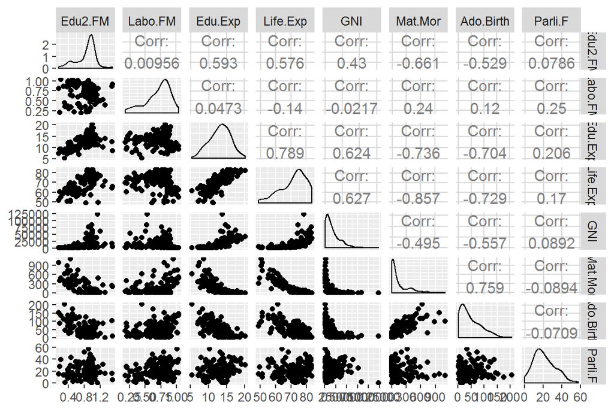

```r
library(GGally)
library(corrplot)
ggpairs(human)
```

- compute the correlation matrix and visualize it with corrplot

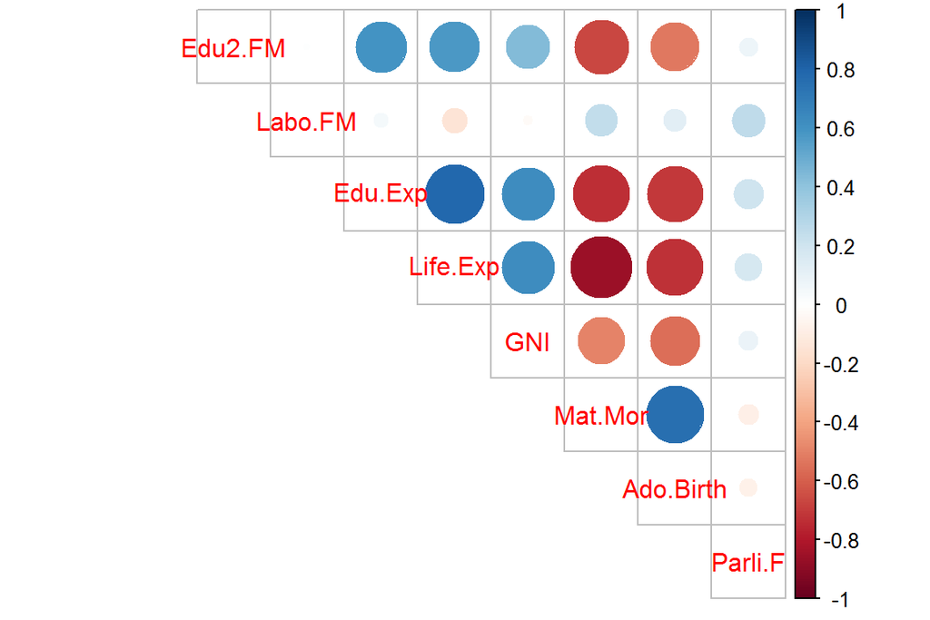

```r
library(dplyr)
cor(human) %>% corrplot(type='upper', tl.pos = 'd')
```

From the picture, we can see that：  
1. Mat.Mor has negative relationships with Edu2.FM, Edu,Exp, Life.Exp.  
2. Life.Exp is positively related to Edu.Exp.  
3. Ado.Birth is positively corrected with Mat.Mor, but negatively related to Edu.Exp and Life.Exp.

## 3. PCA on the not standardized human data with the SVD method.

- perform principal component analysis (with the SVD method)

```r
pca_human <- prcomp(human)
s = summary(pca_human)
s
```

```
## Importance of components:
##                              PC1      PC2   PC3   PC4   PC5   PC6    PC7
## Standard deviation     1.854e+04 185.5219 25.19 11.45 3.766 1.566 0.1912
## Proportion of Variance 9.999e-01   0.0001  0.00  0.00 0.000 0.000 0.0000
## Cumulative Proportion  9.999e-01   1.0000  1.00  1.00 1.000 1.000 1.0000
##                           PC8
## Standard deviation     0.1591
## Proportion of Variance 0.0000
## Cumulative Proportion  1.0000
```

- draw a biplot of the principal component representation and the original variables

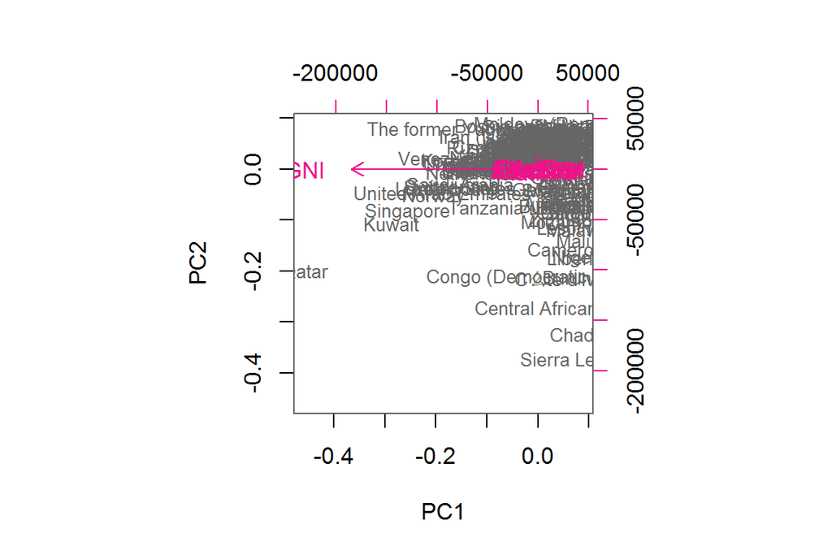

```r
pca_pr=round(100*s$importance[2,],digits=1)
pc_lab=paste0(names(pca_pr),'(',pca_pr,'%)')
biplot(pca_human, choices = 1:2, cex = c(0.8, 1), col = c("grey40", "deeppink2"))
```

The biplot figure with not standardized variable is not clear because the varialbes have different scales and are not compariable.

## 4. PCA on standardized human data

- standardize the variables

```r
human_std <- scale(human)
summary(human_std)
```

```
##     Edu2.FM           Labo.FM           Edu.Exp           Life.Exp
##  Min.   :-2.8189   Min.   :-2.6247   Min.   :-2.7378   Min.   :-2.7188
##  1st Qu.:-0.5233   1st Qu.:-0.5484   1st Qu.:-0.6782   1st Qu.:-0.6425
##  Median : 0.3503   Median : 0.2316   Median : 0.1140   Median : 0.3056
##  Mean   : 0.0000   Mean   : 0.0000   Mean   : 0.0000   Mean   : 0.0000
##  3rd Qu.: 0.5958   3rd Qu.: 0.7350   3rd Qu.: 0.7126   3rd Qu.: 0.6717
##  Max.   : 2.6646   Max.   : 1.6632   Max.   : 2.4730   Max.   : 1.4218
##       GNI             Mat.Mor          Ado.Birth          Parli.F
##  Min.   :-0.9193   Min.   :-0.6992   Min.   :-1.1325   Min.   :-1.8203
##  1st Qu.:-0.7243   1st Qu.:-0.6496   1st Qu.:-0.8394   1st Qu.:-0.7409
##  Median :-0.3013   Median :-0.4726   Median :-0.3298   Median :-0.1403
##  Mean   : 0.0000   Mean   : 0.0000   Mean   : 0.0000   Mean   : 0.0000
##  3rd Qu.: 0.3712   3rd Qu.: 0.1932   3rd Qu.: 0.6030   3rd Qu.: 0.6127
##  Max.   : 5.6890   Max.   : 4.4899   Max.   : 3.8344   Max.   : 3.1850
```

```r
pca_human_std <- prcomp(human_std)
s1=summary(pca_human_std)
s1
```

```
## Importance of components:
##                           PC1    PC2     PC3     PC4     PC5     PC6
## Standard deviation     2.0708 1.1397 0.87505 0.77886 0.66196 0.53631
## Proportion of Variance 0.5361 0.1624 0.09571 0.07583 0.05477 0.03595
## Cumulative Proportion  0.5361 0.6984 0.79413 0.86996 0.92473 0.96069
##                            PC7     PC8
## Standard deviation     0.45900 0.32224
## Proportion of Variance 0.02634 0.01298
## Cumulative Proportion  0.98702 1.00000
```

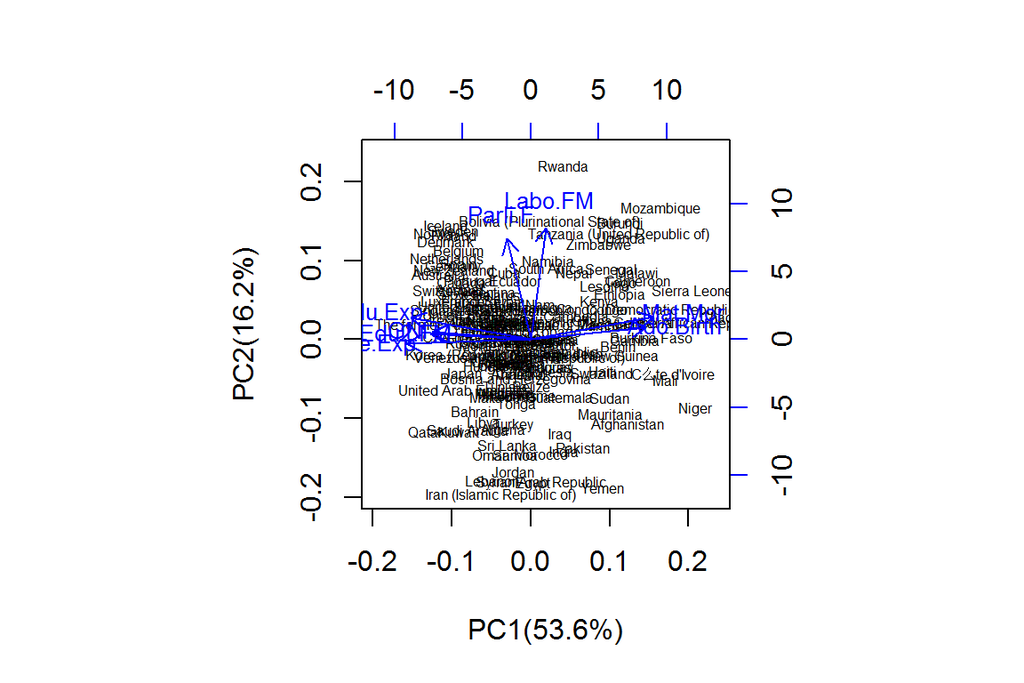

```r
pca_pr=round(100*s1$importance[2,],digits=1)
pc_lab=paste0(names(pca_pr),'(',pca_pr,'%)')
biplot(pca_human_std, choices = 1:2, cex = c(0.5, 0.8), col = c("black", "blue"), xlab=pc_lab[1], ylab=pc_lab[2])
```

The PCA results on reginal data is diifferent on standerized data. when the data is not Standardized, the values of GNI varible is very huge compared to others, so that the GNI is the only varible described in the biplot. However, the relationship can be achieved once the data scaled, we can see from the biplot for pca_human_std,

## 5. interpretations of PCA on the standardized human data

1. Maternal mortality ratio is positively related to adolescent birth rate.
2. Expected years of schooling and life expectancy at birth have a positive correction withthe ratio of Female and Male populations with secondary education in each country.
3. All varibles except Parli.F and Labo.FM have same direction with PC1 axis. the directons of Parli.F and Labo.FM are the same with PC2

## 6. tea dataset

- Load the tea dataset from the package Factominer.

```r
library(FactoMineR)
data(tea)
```

- structure and the dimensions

```r
str(tea)
```

```
## 'data.frame':    300 obs. of  36 variables:
##  $ breakfast       : Factor w/ 2 levels "breakfast","Not.breakfast": 1 1 2 2 1 2 1 2 1 1 ...
##  $ tea.time        : Factor w/ 2 levels "Not.tea time",..: 1 1 2 1 1 1 2 2 2 1 ...
##  $ evening         : Factor w/ 2 levels "evening","Not.evening": 2 2 1 2 1 2 2 1 2 1 ...
##  $ lunch           : Factor w/ 2 levels "lunch","Not.lunch": 2 2 2 2 2 2 2 2 2 2 ...
##  $ dinner          : Factor w/ 2 levels "dinner","Not.dinner": 2 2 1 1 2 1 2 2 2 2 ...
##  $ always          : Factor w/ 2 levels "always","Not.always": 2 2 2 2 1 2 2 2 2 2 ...
##  $ home            : Factor w/ 2 levels "home","Not.home": 1 1 1 1 1 1 1 1 1 1 ...
##  $ work            : Factor w/ 2 levels "Not.work","work": 1 1 2 1 1 1 1 1 1 1 ...
##  $ tearoom         : Factor w/ 2 levels "Not.tearoom",..: 1 1 1 1 1 1 1 1 1 2 ...
##  $ friends         : Factor w/ 2 levels "friends","Not.friends": 2 2 1 2 2 2 1 2 2 2 ...
##  $ resto           : Factor w/ 2 levels "Not.resto","resto": 1 1 2 1 1 1 1 1 1 1 ...
##  $ pub             : Factor w/ 2 levels "Not.pub","pub": 1 1 1 1 1 1 1 1 1 1 ...
##  $ Tea             : Factor w/ 3 levels "black","Earl Grey",..: 1 1 2 2 2 2 2 1 2 1 ...
##  $ How             : Factor w/ 4 levels "alone","lemon",..: 1 3 1 1 1 1 1 3 3 1 ...
```

[output cut: 22 more lines]

```r
dim(tea)
```

```
## [1] 300  36
```

- column names to keep in the dataset

```r
keep_columns <- c("Tea", "How", "how", "sugar", "where", "lunch")
tea_time <- dplyr::select(tea, one_of(keep_columns))
```

- look at the summaries and structure of the data

```r
summary(tea_time)
```

```
##         Tea         How                      how           sugar
##  black    : 74   alone:195   tea bag           :170   No.sugar:155
##  Earl Grey:193   lemon: 33   tea bag+unpackaged: 94   sugar   :145
##  green    : 33   milk : 63   unpackaged        : 36
##                  other:  9
##                   where           lunch
##  chain store         :192   lunch    : 44
##  chain store+tea shop: 78   Not.lunch:256
##  tea shop            : 30
##
```

```r
str(tea_time)
```

```
## 'data.frame':    300 obs. of  6 variables:
##  $ Tea  : Factor w/ 3 levels "black","Earl Grey",..: 1 1 2 2 2 2 2 1 2 1 ...
##  $ How  : Factor w/ 4 levels "alone","lemon",..: 1 3 1 1 1 1 1 3 3 1 ...
##  $ how  : Factor w/ 3 levels "tea bag","tea bag+unpackaged",..: 1 1 1 1 1 1 1 1 2 2 ...
##  $ sugar: Factor w/ 2 levels "No.sugar","sugar": 2 1 1 2 1 1 1 1 1 1 ...
##  $ where: Factor w/ 3 levels "chain store",..: 1 1 1 1 1 1 1 1 2 2 ...
##  $ lunch: Factor w/ 2 levels "lunch","Not.lunch": 2 2 2 2 2 2 2 2 2 2 ...
```

- visualize the dataset

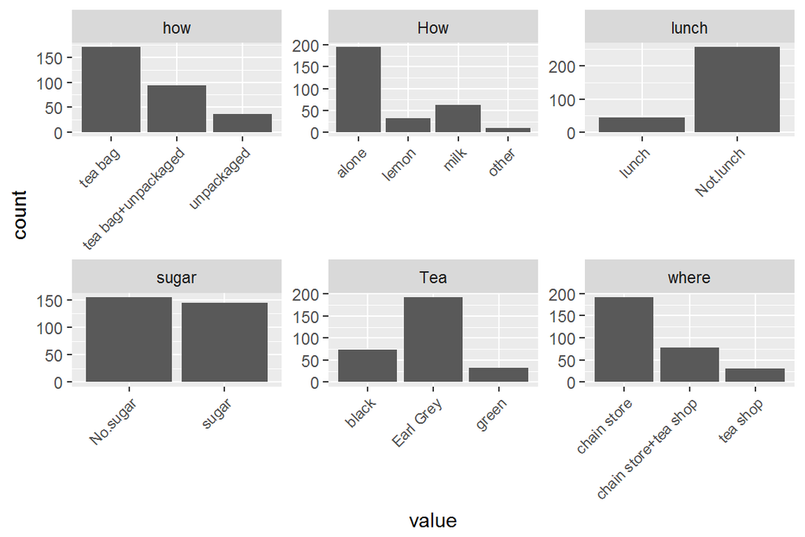

```r
library(tidyr)
library(ggplot2)
gather(tea_time) %>% ggplot(aes(value)) + facet_wrap("key", scales = "free") + geom_bar() + theme(axis.text.x = element_text(angle = 45, hjust = 1, size = 8))
```

* multiple correspondence analysis

```r
mca <- MCA(tea_time, graph = FALSE)
summary(mca)
```

```
##
## Call:
## MCA(X = tea_time, graph = FALSE)
##
##
## Eigenvalues
##                        Dim.1   Dim.2   Dim.3   Dim.4   Dim.5   Dim.6
## Variance               0.279   0.261   0.219   0.189   0.177   0.156
## % of var.             15.238  14.232  11.964  10.333   9.667   8.519
## Cumulative % of var.  15.238  29.471  41.435  51.768  61.434  69.953
##                        Dim.7   Dim.8   Dim.9  Dim.10  Dim.11
## Variance               0.144   0.141   0.117   0.087   0.062
## % of var.              7.841   7.705   6.392   4.724   3.385
## Cumulative % of var.  77.794  85.500  91.891  96.615 100.000
##
## Individuals (the 10 first)
##                       Dim.1    ctr   cos2    Dim.2    ctr   cos2    Dim.3
## 1                  | -0.298  0.106  0.086 | -0.328  0.137  0.105 | -0.327
## 2                  | -0.237  0.067  0.036 | -0.136  0.024  0.012 | -0.695
## 3                  | -0.369  0.162  0.231 | -0.300  0.115  0.153 | -0.202
## 4                  | -0.530  0.335  0.460 | -0.318  0.129  0.166 |  0.211
## 5                  | -0.369  0.162  0.231 | -0.300  0.115  0.153 | -0.202
## 6                  | -0.369  0.162  0.231 | -0.300  0.115  0.153 | -0.202
## 7                  | -0.369  0.162  0.231 | -0.300  0.115  0.153 | -0.202
## 8                  | -0.237  0.067  0.036 | -0.136  0.024  0.012 | -0.695
## 9                  |  0.143  0.024  0.012 |  0.871  0.969  0.435 | -0.067
## 10                 |  0.476  0.271  0.140 |  0.687  0.604  0.291 | -0.650
##                       ctr   cos2
## 1                   0.163  0.104 |
## 2                   0.735  0.314 |
## 3                   0.062  0.069 |
## 4                   0.068  0.073 |
## 5                   0.062  0.069 |
## 6                   0.062  0.069 |
## 7                   0.062  0.069 |
## 8                   0.735  0.314 |
## 9                   0.007  0.003 |
## 10                  0.643  0.261 |
##
## Categories (the 10 first)
```

[output cut: 16 more lines]

```
## lemon                0.035   3.226 |   1.329  14.771   0.218   8.081 |
## milk                 0.020   2.422 |   0.013   0.003   0.000   0.116 |
## other                0.102   5.534 |  -2.524  14.526   0.197  -7.676 |
## tea bag              0.161  -6.941 |  -0.065   0.183   0.006  -1.287 |
## tea bag+unpackaged   0.478  11.956 |   0.019   0.009   0.000   0.226 |
## unpackaged           0.141  -6.482 |   0.257   0.602   0.009   1.640 |
##
## Categorical variables (eta2)
##                      Dim.1 Dim.2 Dim.3
## Tea                | 0.126 0.108 0.410 |
## How                | 0.076 0.190 0.394 |
## how                | 0.708 0.522 0.010 |
## sugar              | 0.065 0.001 0.336 |
## where              | 0.702 0.681 0.055 |
## lunch              | 0.000 0.064 0.111 |
```

- visualize MCA

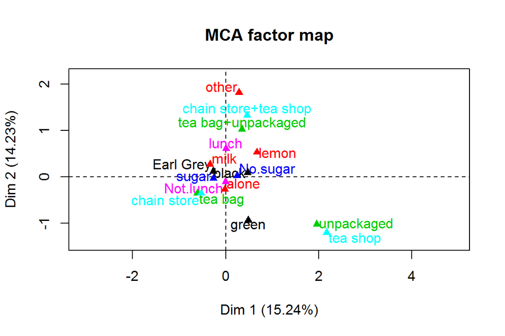

```r
plot(mca, invisible=c("ind"), habillage = "quali")
```

The tea_time data show how people drink tea from 300 cases about how, How, lunch, suger, tea, where. In the biplot, each color represents a variable. From the plot, we can see:

1. People are likely to a combination of milk, Earl Grey and sugar.
2. Tea bag and chain store have a close link.